# Bayesian GLMM Part10

Author

Murray Logan

Published

09/09/2025

# 1 Preparations

Load the necessary libraries

```r
library(broom) # for tidy output
library(knitr) # for kable
library(effects) # for partial effects plots
library(emmeans) # for estimating marginal means
library(MASS) # for glm.nb
library(tidyverse) # for data wrangling
library(brms)
library(tidybayes)
library(bayesplot)
library(broom.mixed)
library(rstan)
library(patchwork)
library(modelsummary)
library(DHARMa)
source("helperFunctions.R")
```

# 2 Original data

```r
ltmp <- read_csv(file = "../data/ltmp_full.csv")
glimpse(ltmp)
```

[output not shown]

# 3 Data processing

```r
coral_fams <- ltmp |>
  filter(HC > 0) |>
  pull(FAMILY_2021) |>
  unique()
ltmp <- ltmp |>
  filter(FAMILY_2021 %in% coral_fams) |>
  dplyr::rename(P_CODE = P_CODE.y) |>
  distinct() |>
  group_by(P_CODE, AIMS_REEF_NAME, REPORT_YEAR, SITE_NO, TRANSECT_NO) |>
  summarise(
    HC = sum(HC, na.rm = TRUE),
    n.points = sum(n.points),
    total.points = unique(total.points)
  ) |>
  ungroup() |>
  dplyr::select(AIMS_REEF_NAME, REPORT_YEAR, SITE_NO, TRANSECT_NO, HC, n.points, total.points) |>
  filter(!is.na(AIMS_REEF_NAME)) |>
  droplevels()
write_csv(ltmp, file = "../data/ltmp.csv")
rm("ltmp")
gc()
```

# 4 Scenario

For over 35 years, the AIMS long term monitoring program has performed benthic surveys of coral reefs on the Great Barrier Reef (GBR). To do so the team uses two main survey techniques 1) Manta Tow and 2) Photo transects. The current example focuses on data collected using the later technique. Within each reef, there are three sites on the north east flank and within each site there are five permanent transects. Every year, the team return and take photos every meter along the transects. Once back in the laboratory, five points from every photo are scored according to what is represented underneath the point.

The main objective of long-term monitoring is to be able to report on status and trends. Specifically, what is the status of each major benthic group (such as hard coral, soft coral and macroalgae) and how are they changing (particularly in response to major disturbances).

For this example, we will focus on a single reef (Agincourt Reef No.1).

# 5 Read in the data

```r
ltmp <- read_csv("../data/ltmp.csv", trim_ws = TRUE)
glimpse(ltmp)
```

```
Rows: 22,125
Columns: 7
$ AIMS_REEF_NAME <chr> "Arlington Reef", "Arlington Reef", "Arlington Reef", "…
$ REPORT_YEAR    <dbl> 2006, 2006, 2006, 2006, 2006, 2006, 2006, 2006, 2006, 2…
$ SITE_NO        <dbl> 1, 1, 1, 1, 1, 2, 2, 2, 2, 2, 3, 3, 3, 3, 3, 1, 1, 1, 1…
$ TRANSECT_NO    <dbl> 1, 2, 3, 4, 5, 1, 2, 3, 4, 5, 1, 2, 3, 4, 5, 1, 2, 3, 4…
$ HC             <dbl> 10.00000, 10.50000, 10.50000, 8.50000, 25.00000, 19.000…
$ n.points       <dbl> 20, 21, 21, 17, 50, 38, 43, 28, 30, 40, 55, 35, 32, 40,…
$ total.points   <dbl> 200, 200, 200, 200, 200, 200, 200, 200, 196, 200, 200, …
```

| AIMS_REEF_NAME | REPORT_YEAR | SITE_NO | TRANSECT_NO | HC | n.points | total.points |
| --- | --- | --- | --- | --- | --- | --- |
| Arlington Reef | 2006 | 1 | 1 | 10.0 | 20 | 200 |
| Arlington Reef | 2006 | 1 | 2 | 10.5 | 21 | 200 |

**glimpse**

```r
glimpse(ltmp)
```

```
Rows: 22,125
Columns: 7
$ AIMS_REEF_NAME <chr> "Arlington Reef", "Arlington Reef", "Arlington Reef", "…
$ REPORT_YEAR    <dbl> 2006, 2006, 2006, 2006, 2006, 2006, 2006, 2006, 2006, 2…
$ SITE_NO        <dbl> 1, 1, 1, 1, 1, 2, 2, 2, 2, 2, 3, 3, 3, 3, 3, 1, 1, 1, 1…
$ TRANSECT_NO    <dbl> 1, 2, 3, 4, 5, 1, 2, 3, 4, 5, 1, 2, 3, 4, 5, 1, 2, 3, 4…
$ HC             <dbl> 10.00000, 10.50000, 10.50000, 8.50000, 25.00000, 19.000…
$ n.points       <dbl> 20, 21, 21, 17, 50, 38, 43, 28, 30, 40, 55, 35, 32, 40,…
$ total.points   <dbl> 200, 200, 200, 200, 200, 200, 200, 200, 196, 200, 200, …
```

**head**

```r
## Explore the first 6 rows of the data
head(ltmp)
```

```
# A tibble: 6 × 7
  AIMS_REEF_NAME REPORT_YEAR SITE_NO TRANSECT_NO    HC n.points total.points
  <chr>                <dbl>   <dbl>       <dbl> <dbl>    <dbl>        <dbl>
1 Arlington Reef        2006       1           1  10         20          200
2 Arlington Reef        2006       1           2  10.5       21          200
3 Arlington Reef        2006       1           3  10.5       21          200
4 Arlington Reef        2006       1           4   8.5       17          200
5 Arlington Reef        2006       1           5  25         50          200
6 Arlington Reef        2006       2           1  19         38          200
```

**str**

```r
str(ltmp)
```

```
spc_tbl_ [22,125 × 7] (S3: spec_tbl_df/tbl_df/tbl/data.frame)
 $ AIMS_REEF_NAME: chr [1:22125] "Arlington Reef" "Arlington Reef" "Arlington Reef" "Arlington Reef" ...
 $ REPORT_YEAR   : num [1:22125] 2006 2006 2006 2006 2006 ...
 $ SITE_NO       : num [1:22125] 1 1 1 1 1 2 2 2 2 2 ...
 $ TRANSECT_NO   : num [1:22125] 1 2 3 4 5 1 2 3 4 5 ...
 $ HC            : num [1:22125] 10 10.5 10.5 8.5 25 ...
 $ n.points      : num [1:22125] 20 21 21 17 50 38 43 28 30 40 ...
 $ total.points  : num [1:22125] 200 200 200 200 200 200 200 200 196 200 ...
 - attr(*, "spec")=
  .. cols(
  ..   AIMS_REEF_NAME = col_character(),
  ..   REPORT_YEAR = col_double(),
  ..   SITE_NO = col_double(),
  ..   TRANSECT_NO = col_double(),
  ..   HC = col_double(),
  ..   n.points = col_double(),
  ..   total.points = col_double()
  .. )
 - attr(*, "problems")=<externalptr>
```

**Easystats (datawizard)**

```r
ltmp |> datawizard::data_codebook()
```

```
ltmp (22125 rows and 7 variables, 7 shown)

ID | Name           | Type      | Missings |                 Values |            N
---+----------------+-----------+----------+------------------------+-------------
1  | AIMS_REEF_NAME | character | 0 (0.0%) |    Agincourt Reef No.1 |  418 ( 1.9%)
   |                |           |          |         Arlington Reef |  135 ( 0.6%)
   |                |           |          |          Border Island |  315 ( 1.4%)
   |                |           |          |             Boult Reef |  120 ( 0.5%)
   |                |           |          |        Broomfield Reef |  435 ( 2.0%)
   |                |           |          |            Carter Reef |  315 ( 1.4%)
   |                |           |          |         Centipede Reef |  105 ( 0.5%)
   |                |           |          |           Chicken Reef |  420 ( 1.9%)
   |                |           |          | Chinaman Reef (22-102) |  419 ( 1.9%)
   |                |           |          |           Corbett Reef |   75 ( 0.3%)
   |                |           |          |                  (...) |
---+----------------+-----------+----------+------------------------+-------------
2  | REPORT_YEAR    | numeric   | 0 (0.0%) |           [1995, 2023] |        22125
---+----------------+-----------+----------+------------------------+-------------
3  | SITE_NO        | numeric   | 0 (0.0%) |                      1 | 7378 (33.3%)
   |                |           |          |                      2 | 7374 (33.3%)
   |                |           |          |                      3 | 7373 (33.3%)
---+----------------+-----------+----------+------------------------+-------------
4  | TRANSECT_NO    | numeric   | 0 (0.0%) |                      1 | 4421 (20.0%)
   |                |           |          |                      2 | 4427 (20.0%)
   |                |           |          |                      3 | 4426 (20.0%)
   |                |           |          |                      4 | 4427 (20.0%)
   |                |           |          |                      5 | 4424 (20.0%)
---+----------------+-----------+----------+------------------------+-------------
5  | HC             | numeric   | 0 (0.0%) |             [0, 93.97] |        22125
---+----------------+-----------+----------+------------------------+-------------
6  | n.points       | numeric   | 0 (0.0%) |               [0, 239] |        22125
---+----------------+-----------+----------+------------------------+-------------
7  | total.points   | numeric   | 0 (0.0%) |              [45, 458] |        22125
----------------------------------------------------------------------------------
```

**Skim (modelsummary)**

SITE_NO

Unique

Missing Pct.

Mean

SD

Min

Median

Max

Histogram

REPORT_YEAR

1.0

29

0

2009.8

8.5

1995.0

2010.0

2023.0

[figure not shown]

2.0

29

0

2009.8

8.5

1995.0

2010.0

2023.0

[figure not shown]

3.0

29

0

2009.8

8.5

1995.0

2010.0

2023.0

[figure not shown]

TRANSECT_NO

1.0

5

0

3.0

1.4

1.0

3.0

5.0

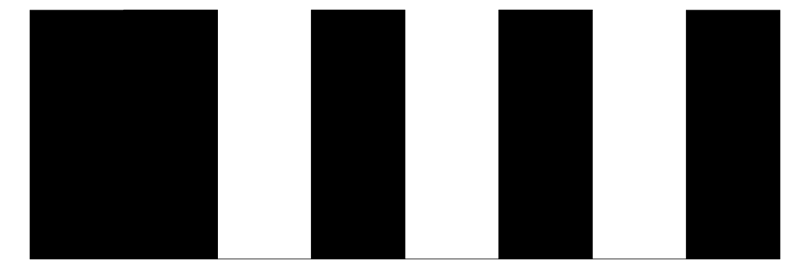

2.0

5

0

3.0

1.4

1.0

3.0

5.0

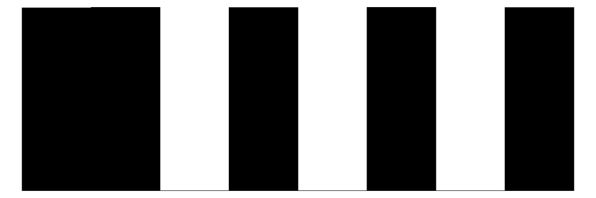

3.0

5

0

3.0

1.4

1.0

3.0

5.0

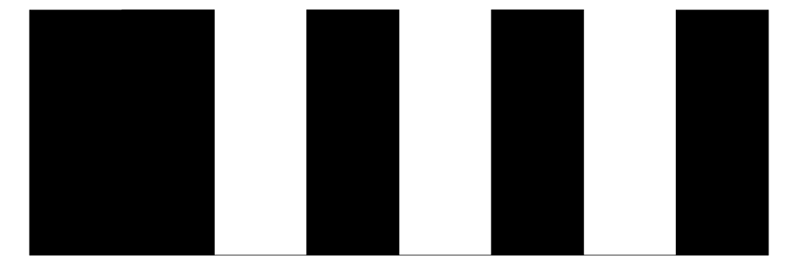

HC

1.0

1762

0

26.2

18.0

0.0

22.5

92.5

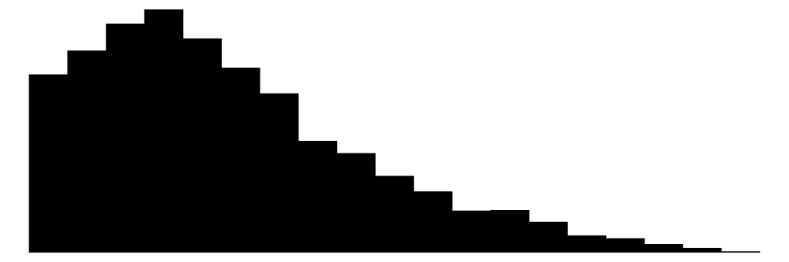

2.0

1686

0

25.2

17.0

0.0

22.0

94.0

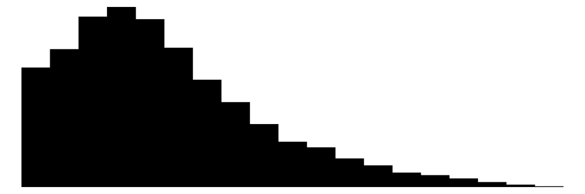

3.0

1633

0

25.1

16.7

0.0

22.7

92.0

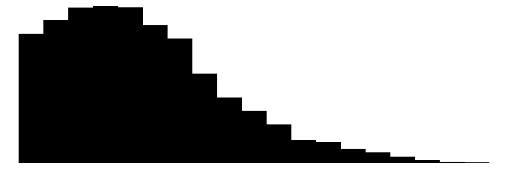

n.points

1.0

178

0

51.9

35.9

0.0

44.0

185.0

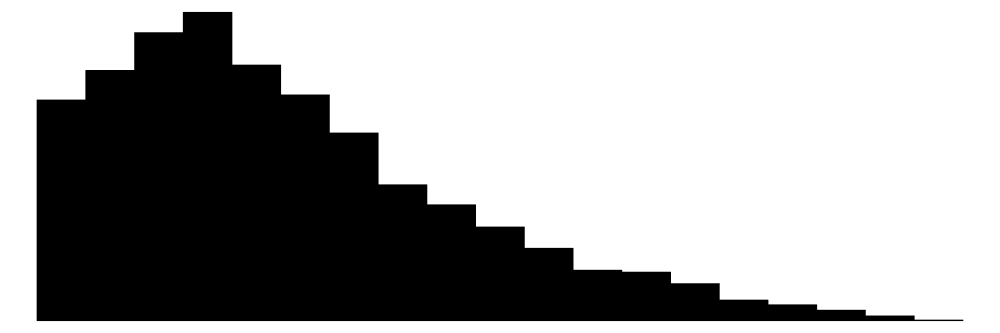

2.0

180

0

50.1

34.0

0.0

44.0

202.0

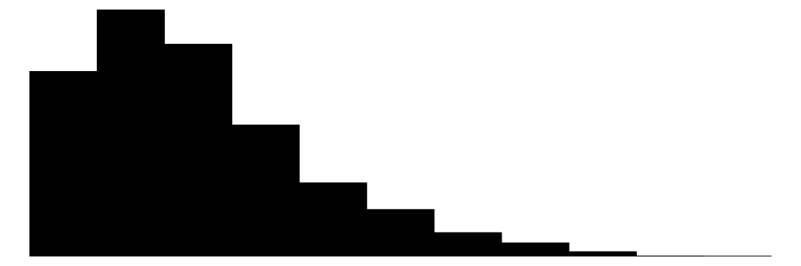

3.0

177

0

49.8

33.4

0.0

45.0

239.0

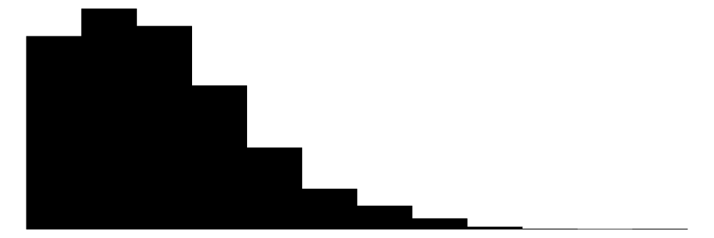

total.points

1.0

125

0

198.6

12.1

65.0

200.0

395.0

[3 more figures not shown]

```r
ltmp |> modelsummary::datasummary_skim(by = "SITE_NO")
```